# Semana 02- code sessions

## Empezemos a poner la data en formato tidy

### Primero pongamos los años en una sola columna

#### Ejemplo Pivot Longer

```r
#### Ejemplo Pivot Longer
#### Ejemplo con datos de los billboards
##### Cada semana esta en una columna, y los valores son la cantidad de reproducciones por semana
head(billboard)

tidyr::billboard %>%
 tidyr::pivot_longer(
   cols = starts_with("wk"), # columnas para transponer en formato long
   names_to = "week",        # string con el nombre de la columna que contendra los nombres de las columnas
   names_prefix = "wk",      # expresion regular (investigen esto) que remueve la parte de los nombres que no nos guste
   values_to = "rank",       # columna nueva que tendra los valores de las columnas transpuestas
   values_drop_na = TRUE     # muchas celdas no tenian valores. Escoge si los conservas o los remueves
 )
```

[output not shown]

#### De vuelta a nuestra tarea

```r
WDI_long<-WDI_long %>%
  # Cada variable debe tener su propia columna
  # 1. Unifica las columnas de año.
  # tidyr::pivot_longer trasnpone K columnas en 2 columnas:
  # una con los nombres de las antiguas columnas, y otra con los valores
  tidyr::pivot_longer(cols = starts_with("x"),
               names_to = "year",
               values_to="value"  )


head(WDI_long)
```

```
## # A tibble: 6 x 5
##   country_name country_code series_name                  year         value
##   <chr>        <chr>        <chr>                        <chr>        <chr>
## 1 Afghanistan  AFG          GDP per capita (current US$) x1960_yr1960 59.773233~
## 2 Afghanistan  AFG          GDP per capita (current US$) x1961_yr1961 59.860899~
## 3 Afghanistan  AFG          GDP per capita (current US$) x1962_yr1962 58.458008~
## 4 Afghanistan  AFG          GDP per capita (current US$) x1963_yr1963 78.706428~
## 5 Afghanistan  AFG          GDP per capita (current US$) x1964_yr1964 82.095306~
## 6 Afghanistan  AFG          GDP per capita (current US$) x1965_yr1965 101.10832~
```

### Aún falta: Hay que poner cada indicador en su propia columna.

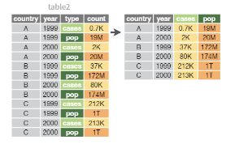

#### Ejemplo pivot wider

```r
#### Ejemplo pivot wider
#### Ejemplo con datos de los us_rent_income
##### Los estimados y los margenes de error estan la misma columna
head(us_rent_income)
```

```
## # A tibble: 6 x 5
##   GEOID NAME    variable estimate   moe
##   <chr> <chr>   <chr>       <dbl> <dbl>
## 1 01    Alabama income      24476   136
## 2 01    Alabama rent          747     3
## 3 02    Alaska  income      32940   508
## 4 02    Alaska  rent         1200    13
## 5 04    Arizona income      27517   148
## 6 04    Arizona rent          972     4
```

```r
# Transforma la data generando una columna para los estimados y otra para los margenes de error
us_rent_income %>%
  pivot_wider(names_from = variable,         # La variable con las categorias que vas a individualizar
              values_from = c(estimate, moe) # La(s) variable(s) que tienen los valores a repartir entre las nuevas columnas
              )
```

```
## # A tibble: 52 x 6
##    GEOID NAME                 estimate_income estimate_rent moe_income moe_rent
##    <chr> <chr>                          <dbl>         <dbl>      <dbl>    <dbl>
##  1 01    Alabama                        24476           747        136        3
##  2 02    Alaska                         32940          1200        508       13
##  3 04    Arizona                        27517           972        148        4
##  4 05    Arkansas                       23789           709        165        5
##  5 06    California                     29454          1358        109        3
##  6 08    Colorado                       32401          1125        109        5
##  7 09    Connecticut                    35326          1123        195        5
##  8 10    Delaware                       31560          1076        247       10
##  9 11    District of Columbia           43198          1424        681       17
## 10 12    Florida                        25952          1077         70        3
## # ... with 42 more rows
```

#### De vuelta a nuestra tarea

```r
#### De vuelta a nuestra tarea

# WDI_long<-WDI_long %>%
#  # 2. Asigna una columna nueva a cada indicador
#   # tidyr::pivot_____() selecciona los valores en una columna y los usa para
#   # nombrar nuevas variables. Luego rellena estas columnas con los valores que le indiques
#   tidyr::_____(names_from = c("series_name"),
#               values_from= value)
```

```r
WDI_long<-WDI_long %>%
 # 2. Asigna una columna nueva a cada indicador
  # tidyr::pivot_wider() selecciona los valores en una columna y los usa para
  # nombrar nuevas variables. Luego rellena estas columnas con los valores que le indiques
  tidyr::pivot_wider(names_from = c("series_name"),
              values_from= value)
```

### Corrijamos detalles menores de nombres y formato.

```r
WDI_long<-WDI_long %>%
  # 3. Put more code-firendly names (These are too long, and have spaces)
  dplyr::rename(gdp_pc="GDP per capita (current US$)",
         population="Population, total",
         gdp="GDP (current US$)",
         life_exp="Life expectancy at birth, total (years)") %>%
  # 4. change format to numeric
  dplyr::mutate_at(vars(gdp, gdp_pc,life_exp, population), as.numeric) %>%
  # 5. fix the years column: x1961_yr1961 get last 4 characters
  dplyr::mutate(year=substr(year,
                            stringr::str_length(year)-3,
                            stringr::str_length(year))) %>%
  # 6. Remove year 2020 since it has too many missing estimates to date
  dplyr::mutate(year=as.numeric(year)) %>%
  dplyr::filter(year<2020)
```

### Finalmente, junta los nombres de cada continente (join)

#### Breve apartado sobre joins: Junta datos provenientes de fuentes diferentes.

Es muy poco probable que todos los datos que necesitamos estén en un solo lugar. En el caso anterior tuvimos que conseguir una base de datos de codigo país y continente para añadir estos últimos a la data.

Supongamos que queremos unir las tablas A y B mediante la columna “cédula”. Hay al menos 4 maneras de proceder:

- **inner_join()**: Preservo a los individuos cuyas cédulas estan en A y B.
- **left_join()**: Preservo a los individuos cuyas cédulas estan en A. Si no aparecen en B, simplemente no tendrán la información proveniente de esta tabla.
- **right_join()**: Preservo a los individuos cuyas cédulas estan en B. Si no aparecen en A, simplemente no tendrán la información proveniente de esta tabla.
- **full_join()**: Preservo a los individuos cuyas cédulas estan en A ó B. Todos serán preservados, pero los que no aparecen en A y B tendrán información incompleta.

En resumen:

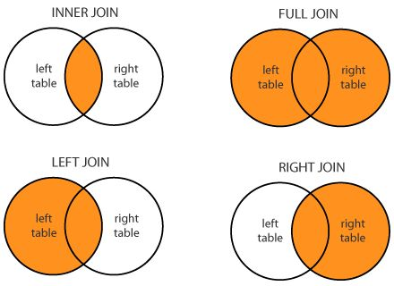

#### Ejemplo con los datos de aerolineas

```r
head(flights)
```

```
## # A tibble: 6 x 19
##    year month   day dep_time sched_dep_time dep_delay arr_time sched_arr_time
##   <int> <int> <int>    <int>          <int>     <dbl>    <int>          <int>
## 1  2013     1     1      517            515         2      830            819
## 2  2013     1     1      533            529         4      850            830
## 3  2013     1     1      542            540         2      923            850
## 4  2013     1     1      544            545        -1     1004           1022
## 5  2013     1     1      554            600        -6      812            837
## 6  2013     1     1      554            558        -4      740            728
## # ... with 11 more variables: arr_delay <dbl>, carrier <chr>, flight <int>,
## #   tailnum <chr>, origin <chr>, dest <chr>, air_time <dbl>, distance <dbl>,
## #   hour <dbl>, minute <dbl>, time_hour <dttm>
```

```r
head(airlines)
```

```
## # A tibble: 6 x 2
##   carrier name
##   <chr>   <chr>
## 1 9E      Endeavor Air Inc.
## 2 AA      American Airlines Inc.
## 3 AS      Alaska Airlines Inc.
## 4 B6      JetBlue Airways
## 5 DL      Delta Air Lines Inc.
## 6 EV      ExpressJet Airlines Inc.
```

```r
#### Ejemplo con los datos de aerolineas

#### Que aerolineas tuvieron los mayores retrasos en las llegadas
####
#### 1. Join `airlines` to `flights`
#### 2. Compute and order the average arrival delays by airline. Display full names, no codes.

flights %>%
  tidyr::drop_na(arr_delay) %>%
  dplyr::left_join(airlines, by="carrier") %>%
  dplyr::group_by(name) %>%
  dplyr::summarise(mean_arrival_delays=mean(arr_delay)) %>%
  dplyr::arrange(-mean_arrival_delays)
```

```
## # A tibble: 16 x 2
##    name                        mean_arrival_delays
##    <chr>                                     <dbl>
##  1 Frontier Airlines Inc.                   21.9
##  2 AirTran Airways Corporation              20.1
##  3 ExpressJet Airlines Inc.                 15.8
##  4 Mesa Airlines Inc.                       15.6
##  5 SkyWest Airlines Inc.                    11.9
##  6 Envoy Air                                10.8
##  7 Southwest Airlines Co.                    9.65
##  8 JetBlue Airways                           9.46
##  9 Endeavor Air Inc.                         7.38
## 10 United Air Lines Inc.                     3.56
## 11 US Airways Inc.                           2.13
## 12 Virgin America                            1.76
## 13 Delta Air Lines Inc.                      1.64
## 14 American Airlines Inc.                    0.364
## 15 Hawaiian Airlines Inc.                   -6.92
## 16 Alaska Airlines Inc.                     -9.93
```

#### De vuelta a nuestra tarea

```r
## Carlos creó el archivo "data/country-and-continent-codes-list.csv" en excel para  que tengamos datos de continentes
## No es que le guste, pero cuando toca, toca.

# Lee los datos y limpialos un poco, then join them
continents<-readr::read_delim("data/country-and-continent-codes-list.csv")

continents<-continents %>%
  janitor::clean_names() %>%
  dplyr::select(continent_name ,three_letter_country_code)

WDI_long<-WDI_long %>%
  # 7. We need continent names: Join the continent names data.
  # there are registers for groups of countries, you need an inner join
  # there are other kinds of join: left, right, full
  dplyr::inner_join(continents,
             by=c("country_code"="three_letter_country_code"))
```

## Echa un vistazo a la data: que piensas

```r
head(WDI_long)
```

```
## # A tibble: 6 x 8
##   country_name country_code  year gdp_pc         gdp life_exp population
##   <chr>        <chr>        <dbl>  <dbl>       <dbl>    <dbl>      <dbl>
## 1 Afghanistan  AFG           1960   59.8  537777811.     32.4    8996967
## 2 Afghanistan  AFG           1961   59.9  548888896.     33.0    9169406
## 3 Afghanistan  AFG           1962   58.5  546666678.     33.5    9351442
## 4 Afghanistan  AFG           1963   78.7  751111191.     34.0    9543200
## 5 Afghanistan  AFG           1964   82.1  800000044.     34.5    9744772
## 6 Afghanistan  AFG           1965  101.  1006666638.     34.9    9956318
## # ... with 1 more variable: continent_name <chr>
```

```r
tail(WDI_long)
```

```
## # A tibble: 6 x 8
##   country_name country_code  year gdp_pc          gdp life_exp population
##   <chr>        <chr>        <dbl>  <dbl>        <dbl>    <dbl>      <dbl>
## 1 Zimbabwe     ZWE           2014  1435. 19495519600      58.4   13586710
## 2 Zimbabwe     ZWE           2015  1445. 19963120600      59.5   13814642
## 3 Zimbabwe     ZWE           2016  1465. 20548678100      60.3   14030338
## 4 Zimbabwe     ZWE           2017  1336. 19015327919.     60.8   14236599
## 5 Zimbabwe     ZWE           2018  1352. 19523622342.     61.2   14438812
## 6 Zimbabwe     ZWE           2019  1156. 16932434839.     61.5   14645473
## # ... with 1 more variable: continent_name <chr>
```

```r
#### Solo hace falta que filtremos la data y nos quedemos con un año: 2007
WDI_long_07 <-WDI_long %>%
  dplyr::filter(year==2007)
```

# Ahora si, divertámonos con unos gráficos

## Graficos de distribucion

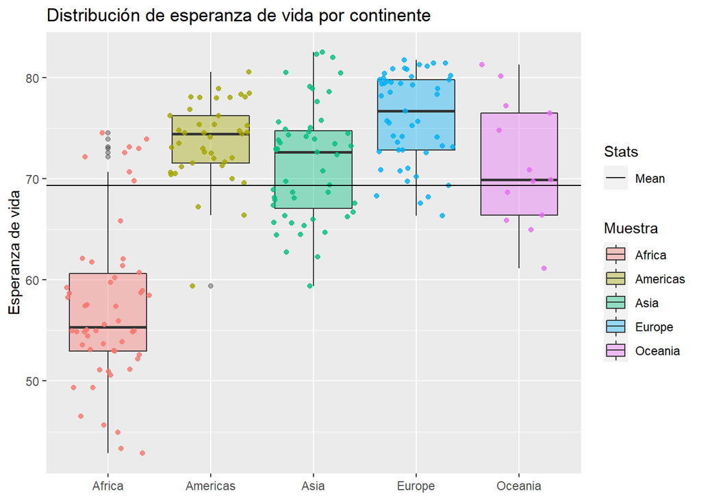

```r
WDI_long_07 %>%
  ggplot(aes(y=life_exp,x=continent_name))+#<<
  # Geom de distribucion por cuartiles (boxplot), por grupos
  geom_boxplot(aes(fill=continent_name), alpha=0.4) +
  # Anade puntos en el fondo
  geom_jitter(aes(color=continent_name),alpha=0.8, show.legend = FALSE) +
  # Geom de lineas verticales
  geom_hline(aes(yintercept = mean(life_exp,na.rm = T),linetype="Mean"))+
  labs(title="Distribución de esperanza de vida por continente",
       fill="Muestra",
       linetype="Stats",
       x=NULL,
       y="Esperanza de vida")
```

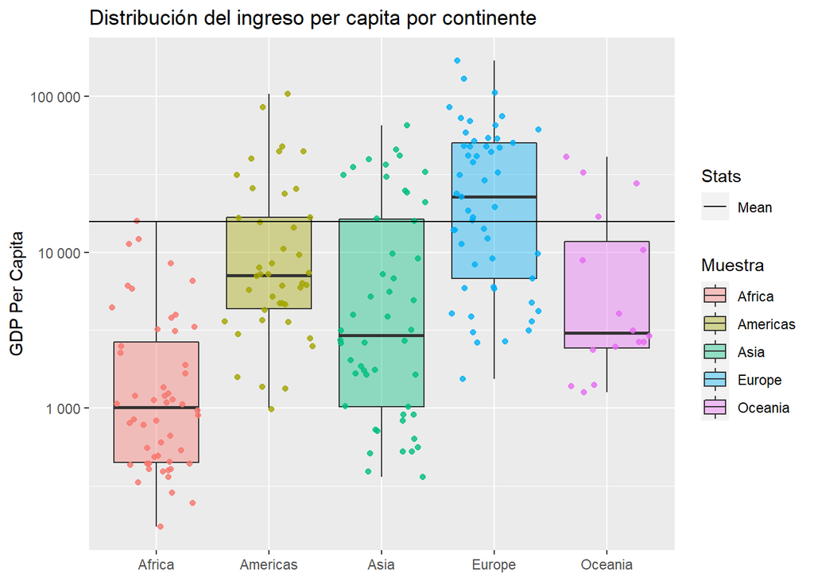

```r
WDI_long_07 %>%
  ggplot(aes(y=gdp_pc,x=continent_name))+
  # Geom de distribucion por cuartiles (boxplot), por grupos
  geom_boxplot(aes(fill=continent_name), alpha=0.4) +
  # Anade puntos en el fondo
  geom_jitter(aes(color=continent_name),alpha=0.8, show.legend = FALSE) +
  # Geom de lineas verticales
  geom_hline(aes(yintercept = mean(gdp_pc,na.rm = T),linetype="Mean"))+
  # Give log scale to Y axis
  scale_y_log10(labels=scales::number_format())+
  labs(title="Distribución del ingreso per capita por continente",
       fill="Muestra",
       linetype="Stats",
       x=NULL,
       y="GDP Per Capita")
```

## Scatter plots

### Una grafica basica

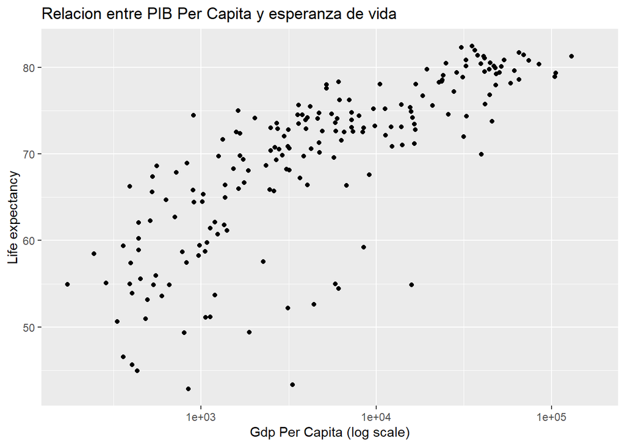

```r
ggplot(data=WDI_long_07,
       mapping = aes(y=life_exp,x=gdp_pc))+
  # coordenadas para una geometria especifica
  geom_point()+
  scale_size_continuous(labels=scales::number_format())+
  scale_x_log10()+
  labs(title="Relacion entre PIB Per Capita y esperanza de vida",
       x="Gdp Per Capita (log scale)",
       y="Life expectancy",
       size="Pop (millions)")
```

### Anademos detalle sobre la poblacion y el detalle

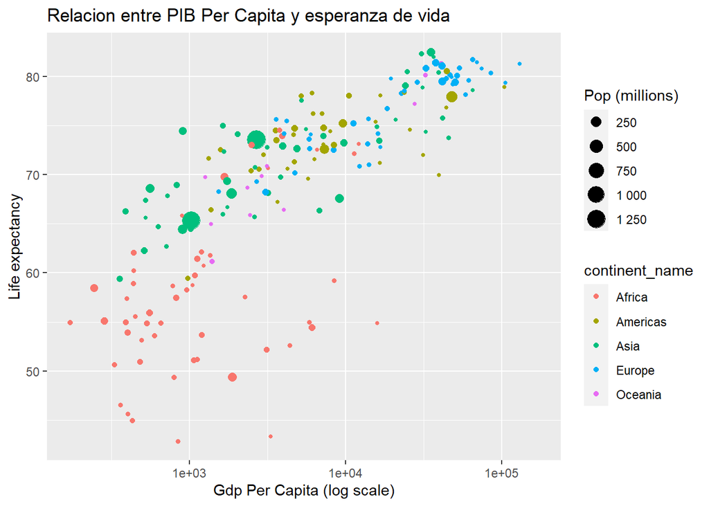

```r
ggplot(data=WDI_long_07,
       mapping = aes(y=life_exp,x=gdp_pc))+
  # coordenadas para una geometria especifica
  geom_point(aes(size=population/1000000,
                 color=continent_name))+
  scale_size_continuous(labels=scales::number_format())+
  scale_x_log10()+
  labs(title="Relacion entre PIB Per Capita y esperanza de vida",
       x="Gdp Per Capita (log scale)",
       y="Life expectancy",
       size="Pop (millions)")
```

### La editorial nos llamo y nos dice que hay que hacer ajustes

Muchos de los lectores del diario no perciben los colores, asi que nos sugieren diferenciar los continentes con la forma de los puntos.

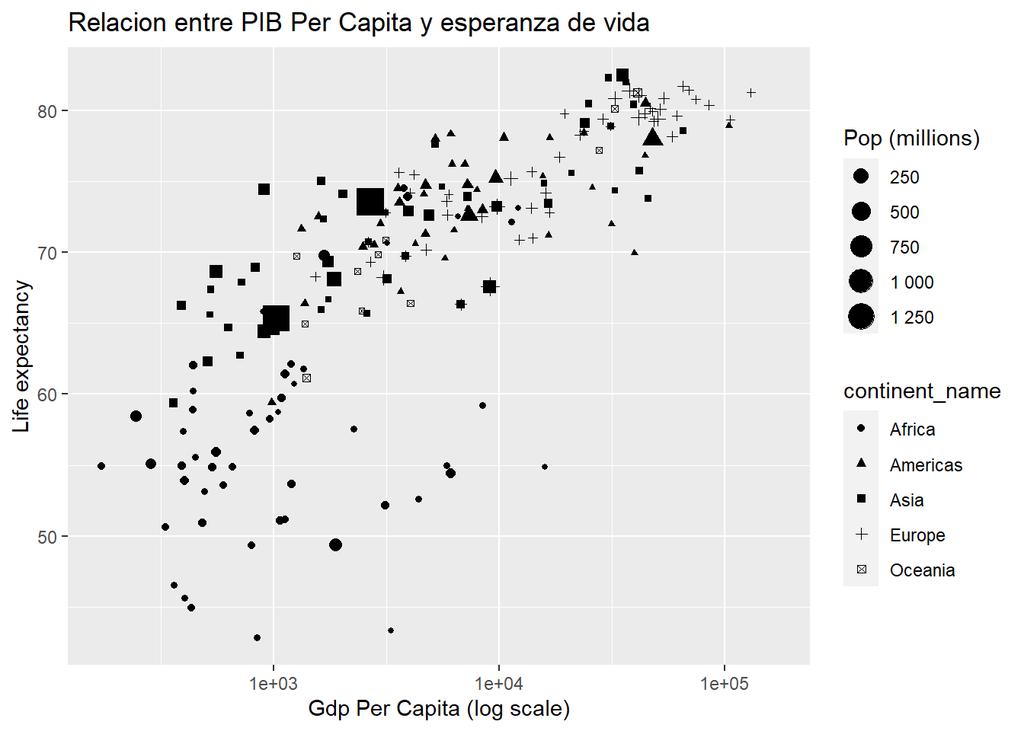

```r
ggplot(data=WDI_long_07,
       mapping = aes(y=life_exp,x=gdp_pc))+
  # coordenadas para una geometria especifica
  geom_point(aes(size=population/1000000,
                 shape=continent_name))+
  scale_size_continuous(labels=scales::number_format())+
  scale_x_log10()+
  labs(title="Relacion entre PIB Per Capita y esperanza de vida",
       x="Gdp Per Capita (log scale)",
       y="Life expectancy",
       size="Pop (millions)")
```